# Bilan Qubs

**DATE DU DERNIER EXPORT DE DONNEES : 14 juin 2024**

## Chiffres clés

**Tableau participation**

| Protocole | Sites | Participants | Participations | Participations vides |
| --- | --- | --- | --- | --- |
| Aspifaune | 189 | 96 | 423 | 15 |
| Noctambules | 154 | 49 | 318 | 29 |
| Opération escargots | 212 | 198 | 405 | 116 |

**Répartition participants/protocoles**

Permet de rendre compte de l’overlap de participation entre protocoles. Combien de participants ont appliqué plusieurs protocoles Qubs ?

|  | Nombre de participants |
| --- | --- |
| aspifaune | 75 |
| escargots | 189 |
| noctambules | 30 |
| aspifaune.noctambule | 15 |
| aspifaune.escargots | 5 |
| noctambules.escargots | 3 |
| aspifaune.noctambules.escargots | 1 |

**Tableau observations**

| Protocole | Taxons Qubs différents | Taxons identifiés | Taxons non identifiés | Pourcentage taxons validés | Nombre de photos |
| --- | --- | --- | --- | --- | --- |
| Aspifaune | 211 | 1476 | 175 | 49.49 | 1541 |
| Noctambules | 144 | 825 | 53 | 53.99 | 872 |
| Opération escargots | 28 | 573 | 170 | 34.59 | 935 |

## Stats spéciales par protocole

**Aspifaune**

Dans le cadre du protocole Aspifaune on totalise 26.4375 m² de surface totale aspirée !

**Noctambules**

Dans le cadre du protocole Noctambules on peut fournir la durée totale de pose des gobelets la nuit : 5317.9 heures.

Sinon je trouve que c’est plus parlant de donner le nombre de nuits différentes échantillonnées : 125 nuits échantillonnées depuis le lancement.

**Opération escargots**

- Nombre total d’individus observés : 1539
- Nombre de taxons différents observés : 28
- Nombre de taxons différents observés et validés : 18
- Nombre d’abris : 212 (97 Coupelles ; 115 Planches)

## Communauté Qubs

**Intractions au total**

Ce tableau donne pour chaque protocole le **nombre total** de validations, de suggestions, de ré-identifications et de commentaires sur participations.

| Protocole | Validations | Suggestions | Ré-identifications | Commentaires participation |
| --- | --- | --- | --- | --- |
| Aspifaune | 2646 | 727 | 440 | 683 |
| Noctambules | 1630 | 356 | 174 | 505 |
| Opération escargots | 570 | 172 | 25 | 444 |

**Participant.es impliqués**

Ce tableau donne pour chaque protocole le **nombre de participant.es** ayant fait des validations, des suggestions, des ré-identifications ou des commentaires sur participation

| Protocole | Validations | Suggestions | Ré-identifications | Commentaires participation |
| --- | --- | --- | --- | --- |
| Aspifaune | 49 | 35 | 35 | 24 |
| Noctambules | 40 | 23 | 16 | 22 |
| Opération escargots | 29 | 26 | 10 | 18 |

## Top taxons

**Top taxons validés**

| taxon | Aspifaune | Noctambules | Opération escargots | Qubs |
| --- | --- | --- | --- | --- |
| L'Amphipode des pelouses | 0 | 1 | 0 | 1 |
| L'Armadille commune | 2 | 3 | 0 | 5 |
| L'Armadille à long museau | 1 | 4 | 0 | 5 |
| L'Aselle des murs | 1 | 2 | 0 | 3 |
| L'Elégante striée | 38 | 2 | 22 | 62 |
| L'Erigone cul-noir | 0 | 3 | 0 | 3 |
| L'Escargot de Bourgogne | 0 | 0 | 8 | 8 |
| L'Escargot turc | 1 | 0 | 3 | 4 |
| L'Orcheselle ceinturée | 7 | 19 | 0 | 26 |
| La Blatte de Vinzi, larve | 2 | 0 | 0 | 2 |

[output cut: 166 more lines]

**Top taxons tout compris**

| taxon | Aspifaune | Noctambules | Opération escargots | Qubs |
| --- | --- | --- | --- | --- |
| L'Amphipode des pelouses | 0 | 2 | 0 | 2 |
| L'Anchomène des champs | 0 | 1 | 0 | 1 |
| L'Armadille commune | 4 | 5 | 0 | 9 |
| L'Armadille granulée | 1 | 0 | 0 | 1 |
| L'Armadille à long museau | 1 | 8 | 0 | 9 |
| L'Aselle des murs | 3 | 2 | 0 | 5 |
| L'Elégante striée | 42 | 2 | 32 | 76 |
| L'Erigone cul-noir | 0 | 3 | 0 | 3 |
| L'Escargot Mourguéta | 0 | 0 | 4 | 4 |
| L'Escargot de Bourgogne | 0 | 0 | 32 | 32 |

[output cut: 236 more lines]

## Camemberts taxo

Cette partie fournit l’information sur la distribution des observations (occurrence) selon différents regroupements d’espèces. Les proportions sont calculées à partir de l’ensemble des observations (sans prendre en compte la validation)

Pour Aspifaune, Noctambules et l’ensemble des données Qubs, sont fournis un donut chart de la distribution des observations en 7 groupes, un tableau des données associées (Regroupement 2a) puis un tableau de la distribution des observations en 12 groupes.

Pour Opération escargots : la distribution des observations entre escargots et limaces.

**Qubs**

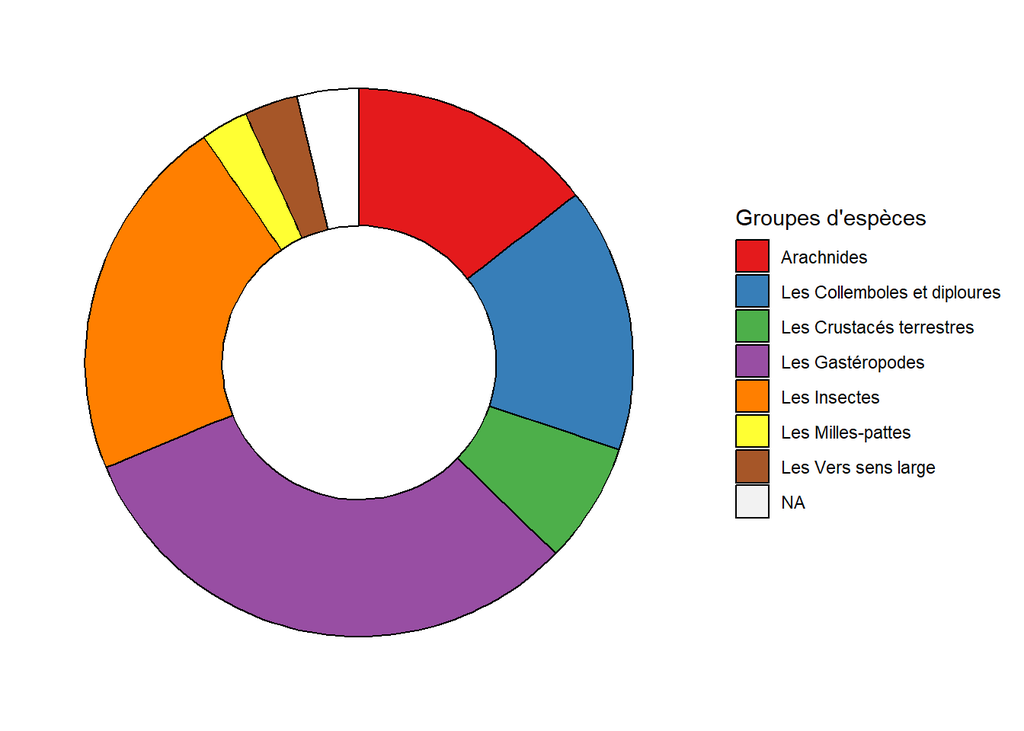

| Regroupement2a | Observations | Observations validées | Proportion groupe |
| --- | --- | --- | --- |
| Arachnides | 417 | 216 | 0.145 |
| Les Collemboles et diploures | 449 | 300 | 0.156 |
| Les Crustacés terrestres | 205 | 109 | 0.071 |
| Les Gastéropodes | 905 | 423 | 0.315 |
| Les Insectes | 622 | 334 | 0.216 |
| Les Milles-pattes | 80 | 57 | 0.028 |
| Les Vers sens large | 91 | 35 | 0.032 |
|  | 105 | 52 | 0.037 |

| Regroupement2b | Observations | Observations validées | Proportion groupe |
| --- | --- | --- | --- |
| Les Acariens | 81 | 54 | 0.028 |
| Les Annélides | 90 | 35 | 0.031 |
| Les Araignées | 308 | 139 | 0.107 |
| Les Autres arachnides | 28 | 23 | 0.01 |
| Les Autres insectes | 255 | 152 | 0.089 |
| Les Carabes et Staphylins | 186 | 109 | 0.065 |
| Les Collemboles et diploures | 449 | 300 | 0.156 |
| Les Crustacés | 205 | 109 | 0.071 |
| Les Escargots | 702 | 366 | 0.244 |
| Les Fourmis | 181 | 73 | 0.063 |

[output cut: 4 more lines]

**Aspifaune**

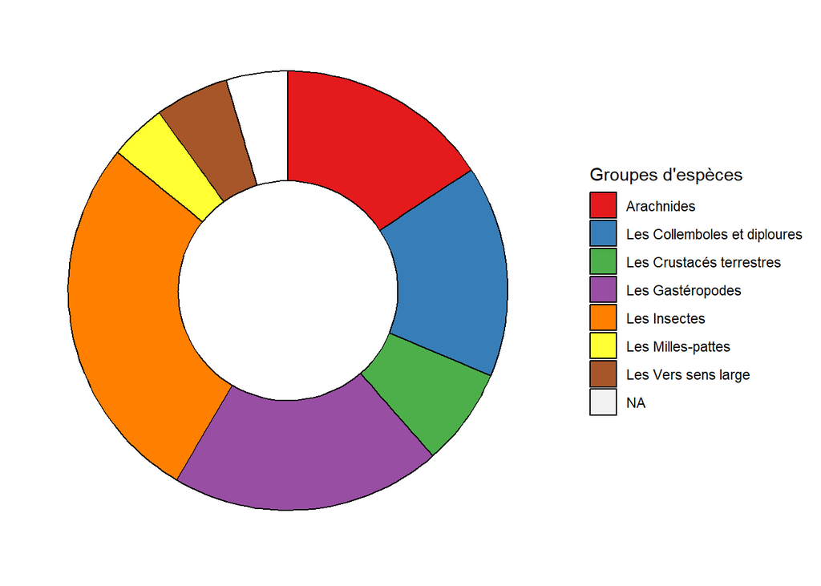

| Regroupement2a | Observations | Observations validées | Proportion groupe |
| --- | --- | --- | --- |
| Arachnides | 232 | 125 | 0.157 |
| Les Collemboles et diploures | 230 | 151 | 0.156 |
| Les Crustacés terrestres | 107 | 56 | 0.072 |
| Les Gastéropodes | 294 | 144 | 0.199 |
| Les Insectes | 404 | 214 | 0.274 |
| Les Milles-pattes | 62 | 46 | 0.042 |
| Les Vers sens large | 80 | 33 | 0.054 |
|  | 67 | 34 | 0.045 |

| Regroupement2b | Observations | Observations validées | Proportion groupe |
| --- | --- | --- | --- |
| Les Acariens | 49 | 28 | 0.033 |
| Les Annélides | 79 | 33 | 0.054 |
| Les Araignées | 167 | 84 | 0.113 |
| Les Autres arachnides | 16 | 13 | 0.011 |
| Les Autres insectes | 199 | 120 | 0.135 |
| Les Carabes et Staphylins | 60 | 37 | 0.041 |
| Les Collemboles et diploures | 230 | 151 | 0.156 |
| Les Crustacés | 107 | 56 | 0.072 |
| Les Escargots | 235 | 111 | 0.159 |
| Les Fourmis | 145 | 57 | 0.098 |

[output cut: 4 more lines]

**Noctambules**

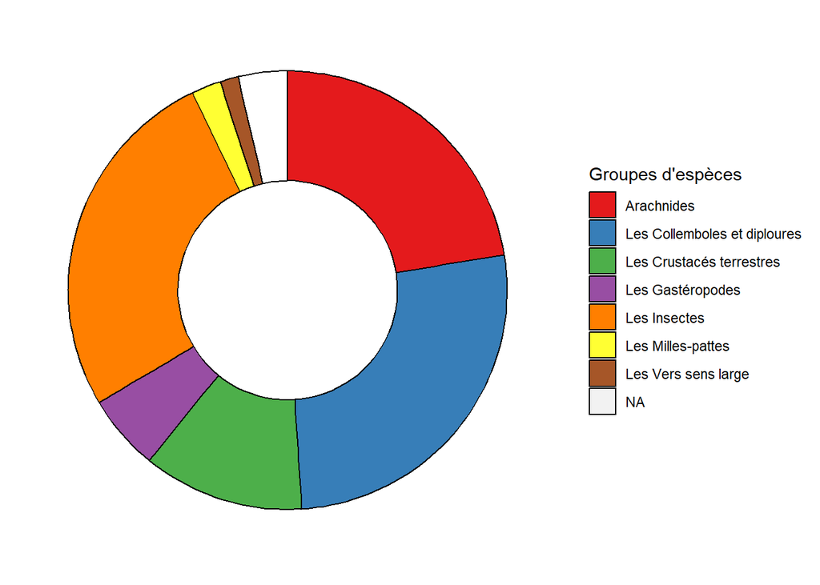

| Regroupement2a | Observations | Observations validées | Proportion groupe |
| --- | --- | --- | --- |
| Arachnides | 185 | 91 | 0.224 |
| Les Collemboles et diploures | 219 | 149 | 0.265 |
| Les Crustacés terrestres | 98 | 53 | 0.119 |
| Les Gastéropodes | 46 | 22 | 0.056 |
| Les Insectes | 218 | 120 | 0.264 |
| Les Milles-pattes | 18 | 11 | 0.022 |
| Les Vers sens large | 11 | 2 | 0.013 |
|  | 30 | 18 | 0.036 |

| Regroupement2b | Observations | Observations validées | Proportion groupe |
| --- | --- | --- | --- |
| Les Acariens | 32 | 26 | 0.039 |
| Les Annélides | 11 | 2 | 0.013 |
| Les Araignées | 141 | 55 | 0.171 |
| Les Autres arachnides | 12 | 10 | 0.015 |
| Les Autres insectes | 56 | 32 | 0.068 |
| Les Carabes et Staphylins | 126 | 72 | 0.153 |
| Les Collemboles et diploures | 219 | 149 | 0.265 |
| Les Crustacés | 98 | 53 | 0.119 |
| Les Escargots | 13 | 7 | 0.016 |
| Les Fourmis | 36 | 16 | 0.044 |

[output cut: 3 more lines]

**Opération escargots**

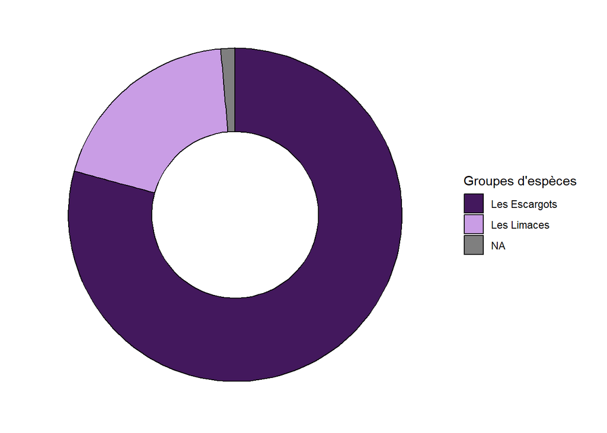

| Regroupement2b | Observations | Observations validées | Proportion groupe |
| --- | --- | --- | --- |
| Les Escargots | 454 | 248 | 0.792 |
| Les Limaces | 111 | 9 | 0.194 |
|  | 8 | 0 | 0.014 |

## Carte des sites

Une carte simplifiée avec l’ensemble des sites d’échantillonnages (tous protocoles confondus).

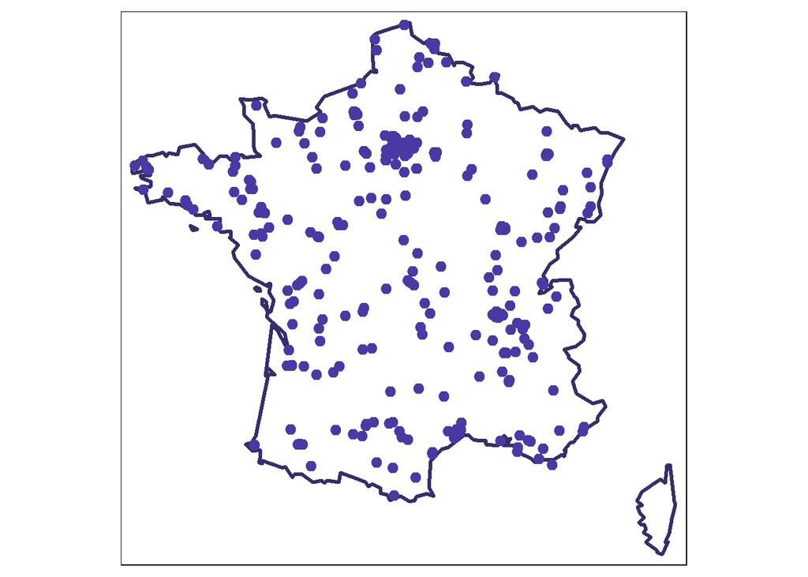